# Instructions for the analysis around the effect of pork barrel of Polish 2020 elections

#Data cleaning

First, we will be looking at loading the data sets and cleaning them.

In the first part of the analysis, we will import a) the population data, b) Rodzina 500+ benefit data, c) Election data from 2015 and 2020, second round d) shapefile (.shp) of the communes in Poland

All the data comes from the governmental websites. all the zip data has been moved to the data_raw folder, and unzipped into data_unzipped.

First, we load our commune shapefile and simplify it, for quicker processing.

```r
library(here)
library(sf)
library(janitor)
library(readxl)
library(plyr)
library(tmap)
library(tidyverse)
library(dplyr)
```

```r
communes <- st_read(here::here("data", "data_unzipped", "Gminy","Gminy.shp"))
communes_simple <- st_simplify(communes)
communes_simple$JPT_KOD_JE <- as.character(communes_simple$JPT_KOD_JE)
communes_simple$kod_teryt <- str_sub(communes_simple$JPT_KOD_JE,
                                 1,
                                 str_length(communes_simple$JPT_KOD_JE)-1)
```

Next, we import the population data - remove unneeded columns and fix incorrect ID codes of commutes. 7 digit Codes are wrongly assigned to Lututow, Piatek, Czerwinsk nad Wisla and Klimotow.

```r
population <- read.csv(here::here("data","data_unzipped", "LUDN_2137_CREL_20210123152322.csv"),
                       sep = ";",
                       encoding = 'UTF-8')

population[c("Jednostka.miary","Atrybut","Rok","X","Plec")]<- NULL

population$Kod <- as.character(population$Kod)

working_age_groups <- c("15-19","20-24","25-29","30-34", "35-39", "40-44","45-49","50-54")

population_cleaned <- population %>%
                        clean_names() %>%
                        filter(wiek %in% working_age_groups)%>%
                        group_by(kod) %>%
                        dplyr::summarise(workingpopulation = sum(as.numeric(wartosc)))
population_cleaned$kod[population_cleaned$kod == '1018042'] <- '1018043'
population_cleaned$kod[population_cleaned$kod == '1004062'] <- '1004063'
population_cleaned$kod[population_cleaned$kod == '1420042'] <- '1420043'
population_cleaned$kod[population_cleaned$kod == '2609032'] <- '2609033'

population_cleaned$kod <- ifelse(str_length(population_cleaned$kod)==6,
                                             paste("0",population_cleaned$kod, sep = ""),
                                         population_cleaned$kod)
```

Then, we move onto Rodzina 500+ data. We run into similar issues we did with population data.

```r
rodzina_500 <- read.csv(here::here("data","data_unzipped","OCHR_3803_CREL_20210124132209.csv"),
                         sep = ";",
                         encoding = 'UTF-8')

rodzina_500[c("Jednostka.miary","Atrybut","X","nazwa")]<- NULL

rodzina_500_cleaned <- rodzina_500 %>%
                          clean_names()%>%
                          pivot_wider(names_from = swiadczenie_wychowawcze, values_from = wartosc)%>%
                          clean_names()

rodzina_500_cleaned$kod <- as.character(rodzina_500_cleaned$kod)
rodzina_500_cleaned$kod <- ifelse(str_length(rodzina_500_cleaned$kod)==6,
                                      paste("0",rodzina_500_cleaned$kod, sep = ""),
                                      rodzina_500_cleaned$kod)

#7 digit Codes are wrongly assigned to Lututow, Piatek, Czerwinsk nad Wisla and Klimotow
rodzina_500_cleaned$kod[rodzina_500_cleaned$kod == '1018042'] = '1018043'
rodzina_500_cleaned$kod[rodzina_500_cleaned$kod == '1004062'] = '1004063'
rodzina_500_cleaned$kod[rodzina_500_cleaned$kod == '1420042'] = '1420043'
rodzina_500_cleaned$kod[rodzina_500_cleaned$kod == '2609032'] = '2609033'
```

Finally, we clean elections data

```r
elections_2020 <-  read.csv(here::here("data","data_unzipped","wyniki_gl_na_kand_po_obwodach_utf8.csv"),
                            sep = ";",
                            encoding = 'UTF-8'
)

elections_2020_cleaned <- elections_2020 %>%
                                  clean_names() %>%
                                  group_by(kod_teryt) %>%
                                  dplyr::summarise(Dudavotes2020 = sum(as.numeric(andrzej_sebastian_duda)),
                                            Trzaskowskivotes2020 = sum(as.numeric(rafal_kazimierz_trzaskowski)),
                                            totalvotes2020 = sum(as.numeric(liczba_glosow_waznych_oddanych_lacznie_na_wszystkich_kandydatow)))
```

```
NAs introduced by coercionNAs introduced by coercionNAs introduced by coercion`summarise()` ungrouping output (override with `.groups` argument)
```

```r
elections_2020_cleaned$Duda_percent_2020 = elections_2020_cleaned$Dudavotes2020/elections_2020_cleaned$totalvotes2020

elections_2020_cleaned$kod_teryt <- as.character(elections_2020_cleaned$kod_teryt)
elections_2020_cleaned$kod_teryt <- ifelse(str_length(elections_2020_cleaned$kod_teryt)==5,
                                         paste("0",elections_2020_cleaned$kod_teryt, sep = ""),
                                         elections_2020_cleaned$kod_teryt
)

elections_2020_cleaned$kod_teryt[elections_2020_cleaned$kod_teryt=='146502'] <- '146501' #(changing Warsaw's code since it was wrong')

elections_2015 <- read_excel(here::here("data","data_unzipped","wyniki_tura2.xls"))

elections_2015_cleaned <- elections_2015 %>%
                                  clean_names()%>%
                                  group_by(teryt_gminy) %>%
                                  dplyr::summarise(Dudavotes2015 = sum(as.numeric(andrzej_sebastian_duda)),
                                            Komorowskivotes2015 = sum(as.numeric(bronislaw_maria_komorowski)),
                                            Totalvotes2015 = sum(as.numeric(andrzej_sebastian_duda)+as.numeric(bronislaw_maria_komorowski))
                                  )
elections_2015_cleaned$teryt_gminy <- as.character(elections_2015_cleaned$teryt_gminy)
elections_2015_cleaned$teryt_gminy <- ifelse(str_length(elections_2015_cleaned$teryt_gminy)==5,
                                         paste("0",elections_2015_cleaned$teryt_gminy, sep = ""),
                                         elections_2015_cleaned$teryt_gminy
)
elections_2015_cleaned$teryt_gminy[elections_2015_cleaned$teryt_gminy=='146502'] <- '146501'


elections_2015_cleaned$Duda_percent_2015 = elections_2015_cleaned$Dudavotes2015/elections_2015_cleaned$Totalvotes2015
```

#Data merge

Now we’re merging the population data, election data, Rodzina 500+ and the shapefile. Terytorial code is contained to 7 digits - the 7th digit can be either a 1 (for an urban commune), 2 (for a rural commune) or 3 (an urban-rural commune). For communes containing mixed areas (urban, rural and urban-rural), 0 number is used with cummulative results. Hence, even though we’re joining strings of different lenghts, the data is essentially whole and correct.

```r
#Now we're merging the population data, election data, Rodzina 500+ and the shapefile.
#Terytorial code is contained to 7 digits - the 7th digit can be either a 1 (for an urban commune),
#2 (for a rural commune) or 3 (an urban-rural commune). For communes containing mixed areas
#(urban, rural and urban-rural), 0 number is used with cummulative results. Hence, even though
#we're joining strings of different lenghts, the data is essentially wholely correct.

join <- left_join(communes_simple,
                  elections_2020_cleaned,
                  by = c("kod_teryt"="kod_teryt")) %>%
        left_join(.,
                  elections_2015_cleaned,
                  by = c("kod_teryt"="teryt_gminy")) %>%
        left_join(.,
                  population_cleaned,
                  by = c("JPT_KOD_JE"="kod")) %>%
        left_join(.,
                  rodzina_500_cleaned,
                  by = c("JPT_KOD_JE"="kod"))
```

#Computation

In this part we will create a couple of new metrics explained further in the paper.

We first obtain 1. Resources spent per working citizen

```r
library(tidyverse)

join$difference2020vs2015 <- (join$Duda_percent_2020-join$Duda_percent_2015)/join$Duda_percent_2015

join$Rn <- join$wydatki_na_swiadczenia_wychowawcze/join$workingpopulation

model1 <- join %>%
  lm(difference2020vs2015 ~
       Rn,
     data=.)
summary(model1)
```

```
Call:
lm(formula = difference2020vs2015 ~ Rn, data = .)

Residuals:
     Min       1Q   Median       3Q      Max
-0.50512 -0.07337 -0.02447  0.05062  1.49307

Coefficients:
              Estimate Std. Error t value Pr(>|t|)
(Intercept)  1.365e-01  1.452e-02   9.395  < 2e-16 ***
Rn          -3.896e-05  9.205e-06  -4.233 2.39e-05 ***
---
Signif. codes:  0 ‘***’ 0.001 ‘**’ 0.01 ‘*’ 0.05 ‘.’ 0.1 ‘ ’ 1

Residual standard error: 0.1234 on 2475 degrees of freedom
Multiple R-squared:  0.007188,  Adjusted R-squared:  0.006786
F-statistic: 17.92 on 1 and 2475 DF,  p-value: 2.39e-05
```

Then we move onto obtaining 2. Average family size receiving 500+ benefit in the area

```r
join$FSc <- join$przecietna_miesieczna_liczba_dzieci_na_ktore_rodziny_otrzymuja_swiadczenie_wychowawcze_w_okresie_od_1_stycznia_2019_do_30_czerwca_2019/
            join$przecietna_miesieczna_liczba_rodzin_otrzymujacych_swiadczenie_wychowawcze_w_okresie_od_1_stycznia_2019_do_30_czerwca_2019

model2 <- join %>%
  lm(difference2020vs2015 ~
       FSc,
     data=.)
summary(model2)
```

```
Call:
lm(formula = difference2020vs2015 ~ FSc, data = .)

Residuals:
     Min       1Q   Median       3Q      Max
-0.43832 -0.07657 -0.02512  0.05262  1.46715

Coefficients:
            Estimate Std. Error t value Pr(>|t|)
(Intercept) -0.33555    0.02923  -11.48   <2e-16 ***
FSc          0.25971    0.01839   14.12   <2e-16 ***
---
Signif. codes:  0 ‘***’ 0.001 ‘**’ 0.01 ‘*’ 0.05 ‘.’ 0.1 ‘ ’ 1

Residual standard error: 0.1192 on 2475 degrees of freedom
Multiple R-squared:  0.0746,    Adjusted R-squared:  0.07422
F-statistic: 199.5 on 1 and 2475 DF,  p-value: < 2.2e-16
```

Then we moved onto obtaining 3. Number of families taking the 500+ benefit in the area

```r
join$Fn <- join$przecietna_miesieczna_liczba_rodzin_otrzymujacych_swiadczenie_wychowawcze_w_okresie_od_1_stycznia_2019_do_30_czerwca_2019/
           join$workingpopulation

model3 <- join %>%
  lm(difference2020vs2015 ~
       Fn,
     data=.)
summary(model3)
```

```
Call:
lm(formula = difference2020vs2015 ~ Fn, data = .)

Residuals:
     Min       1Q   Median       3Q      Max
-0.50065 -0.07418 -0.02384  0.05154  1.48873

Coefficients:
            Estimate Std. Error t value Pr(>|t|)
(Intercept)   0.1393     0.0172   8.101 8.47e-16 ***
Fn           -0.5129     0.1376  -3.727 0.000198 ***
---
Signif. codes:  0 ‘***’ 0.001 ‘**’ 0.01 ‘*’ 0.05 ‘.’ 0.1 ‘ ’ 1

Residual standard error: 0.1235 on 2475 degrees of freedom
Multiple R-squared:  0.005582,  Adjusted R-squared:  0.00518
F-statistic: 13.89 on 1 and 2475 DF,  p-value: 0.000198
```

And lastly, in this case we can build a pultiple regression model based on the three variables

```r
model4 <- join %>%
  lm(difference2020vs2015 ~
       FSc+
       Rn+
       Fn,
     data=.)
summary(model4)
```

```
Call:
lm(formula = difference2020vs2015 ~ FSc + Rn + Fn, data = .)

Residuals:
     Min       1Q   Median       3Q      Max
-0.45568 -0.07352 -0.02280  0.04990  1.43960

Coefficients:
              Estimate Std. Error t value Pr(>|t|)
(Intercept) -2.752e-01  2.978e-02  -9.240  < 2e-16 ***
FSc          3.206e-01  1.911e-02  16.781  < 2e-16 ***
Rn          -6.197e-05  1.422e-05  -4.358 1.36e-05 ***
Fn          -4.890e-01  2.116e-01  -2.311   0.0209 *
---
Signif. codes:  0 ‘***’ 0.001 ‘**’ 0.01 ‘*’ 0.05 ‘.’ 0.1 ‘ ’ 1

Residual standard error: 0.117 on 2473 degrees of freedom
Multiple R-squared:  0.1088,    Adjusted R-squared:  0.1078
F-statistic: 100.7 on 3 and 2473 DF,  p-value: < 2.2e-16
```

#Visualisations

Those can be produced using plyr and tmap.

```r
library(plyr)
library(tmap)

join <- join %>%
  mutate(perc=difference2020vs2015*100)

join$winner <- ifelse(join$Duda_percent_2020>0.5,"Duda","Trzaskowski")

tmap_mode("plot")
```

```
tmap mode set to plotting
```

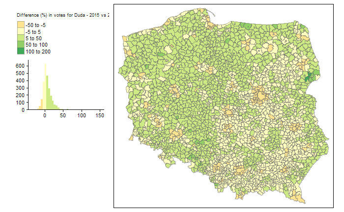

```r
tm_shape(join, name = "JPT_NAZWA_") +
              tm_polygons(col = "perc",
                          id = "JPT_NAZWA_",
                          title = "Difference (%) in votes for Duda - 2015 vs 2020",
                          title.size = 25,
                          breaks = c(-50,-5,5,50,100,200),
                          palette = "RdYlGn",
                          legend.hist = TRUE,
                          border.alpha = 0.5)+
              tm_layout(legend.hist.width = 10,
                        legend.outside = TRUE,
                        legend.outside.position = "left")
```

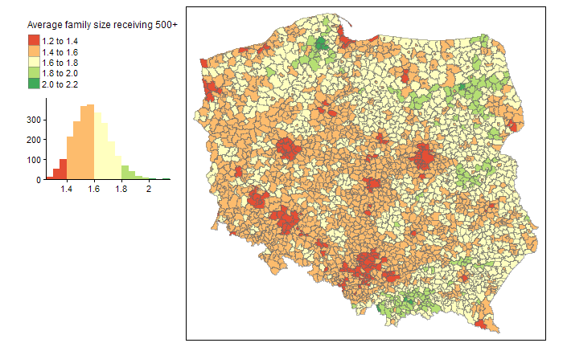

```r
  tm_shape(join, name = "JPT_NAZWA_") +
    tm_polygons(col = "FSc",
                id = "JPT_NAZWA_",
                title = "Average family size receiving 500+",
                palette = "RdYlGn",
                legend.hist = TRUE,
                border.alpha = 0.5)+
    tm_layout(title.size = 20,
              legend.hist.width = 10,
              legend.outside = TRUE,
              legend.outside.position = "left")
```

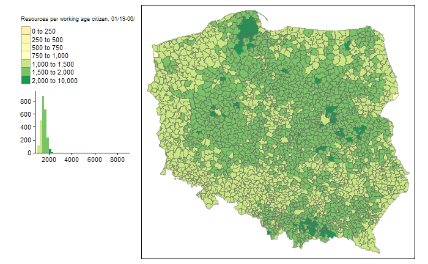

```r
  tm_shape(join, name = "JPT_NAZWA_") +
    tm_polygons(col = "Rn",
                id = "JPT_NAZWA_",
                title = "Resources per working age citizen, 01/19-06/19",
                breaks = c(0,250,500,750,1000,1500,2000,10000),
                palette = "RdYlGn",
                legend.hist = TRUE,
                border.alpha = 0.5)+
    tm_layout(title.size = 20,
              legend.hist.width = 10,
              legend.outside = TRUE,
              legend.outside.position = "left")
```

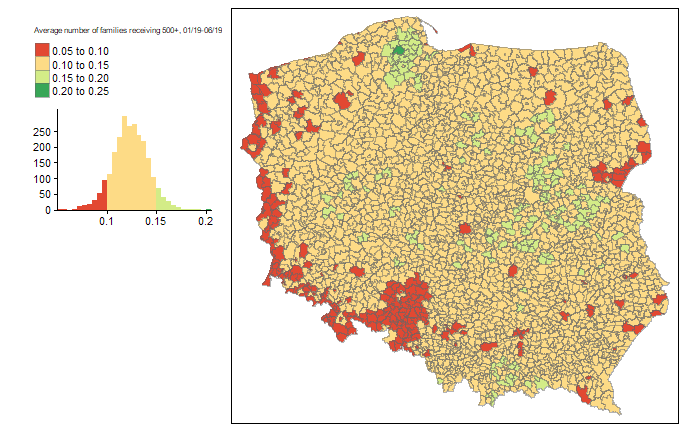

```r
  tm_shape(join, name = "JPT_NAZWA_") +
    tm_polygons(col = "Fn",
                id = "JPT_NAZWA_",
                title = "Average number of families receiving 500+, 01/19-06/19",
                title.size = 25,
                #breaks = c(-50,-5,5,50,100,200),
                palette = "RdYlGn",
                legend.hist = TRUE,
                border.alpha = 0.5)+
    tm_layout(legend.hist.width = 10,
              legend.outside = TRUE,
              legend.outside.position = "left")
```

```r
NA
NA
```

As well as the histogram of family size for Duda voters and Trzaskowski voters

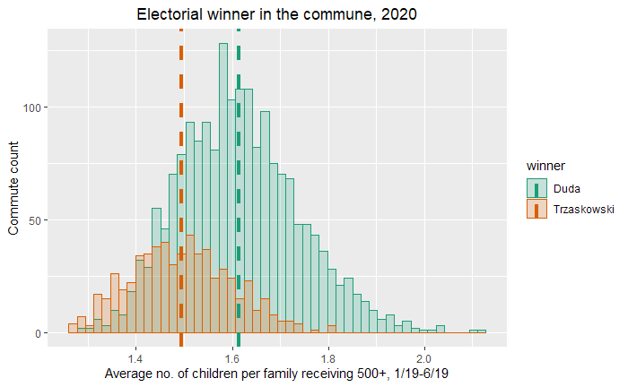

```r
means <- ddply(join, "winner", summarise, grp.mean=mean(FSc))

ggplot(join, aes(x=FSc, fill=winner, color=winner))+
                         geom_histogram(alpha=0.2, position="identity", bins = 50)+
                         geom_vline(data=means, aes(xintercept=grp.mean, color=winner), linetype="dashed", size = 1.5)+
                         labs(title="Electorial winner in the commune, 2020",
                               x="Average no. of children per family receiving 500+, 1/19-6/19",
                               y="Commute count")+
                         theme(plot.title = element_text(hjust=0.5))+
                        scale_color_brewer(palette="Dark2")+
                        scale_fill_brewer(palette="Dark2")
```